[figure not shown]

# Working with annual air quality data with the `{tidyverse}`

Published

December 13, 2022

Abstract

Much of [openair](https://davidcarslaw.github.io/openair/) is set up to work with hourly data from a small handful of sites. However, [openair](https://davidcarslaw.github.io/openair/) also makes it easy to access summary statistics for whole networks. In this document, the power of R and the [tidyverse](https://tidyverse.tidyverse.org) is demonstrated to analyse these large data sets.

```r
library(openair)
library(tidyverse)
```

# 1 Import Data

To import annual data, we use the “data_type” argument in the various `import*()` functions. As we’re working in the [tidyverse](https://tidyverse.tidyverse.org), lets make sure our data is tidy by using the “to_narrow” argument as well. An additional step is also labelling each network with a column of its name, so they can be distinguished later.

Note that, when “data_type” is “annual”, the `import*()` function ignores arguments like “site” and “pollutant”.

The last step is to use `bind_rows()` from [dplyr](https://dplyr.tidyverse.org) to combine all of the data frames together into one.

```r
# import annual averages from all networks
aurn <-
  importAURN(
    year = 2018,
    data_type = "annual",
    to_narrow = TRUE,
    meta = TRUE
  ) %>% mutate(network = "AURN")

aqen <-
  importAQE(
    year = 2018,
    data_type = "annual",
    to_narrow = TRUE,
    meta = TRUE
  ) %>% mutate(network = "AQE")

saqn <-
  importSAQN(
    year = 2018,
    data_type = "annual",
    to_narrow = TRUE,
    meta = TRUE
  ) %>% mutate(network = "SAQN")

waqn <-
  importWAQN(
    year = 2018,
    data_type = "annual",
    to_narrow = TRUE,
    meta = TRUE
  ) %>% mutate(network = "WAQN")

niaq <-
  importNI(
    year = 2018,
    data_type = "annual",
    to_narrow = TRUE,
    meta = TRUE
  ) %>% mutate(network = "NIAQN")

lmam <-
  importLocal(
    year = 2018,
    data_type = "annual",
    to_narrow = TRUE,
    meta = TRUE
  ) %>% mutate(network = "Local")

# bind them together
all_aq <- bind_rows(aurn, aqen, saqn, waqn, niaq, lmam)

# clear up global environment
rm(aurn, aqen, saqn, waqn, niaq, lmam)

# preview
summary(all_aq)
```

```
     code               site                date              species
 Length:13529       Length:13529       Min.   :2018-01-01   Length:13529
 Class :character   Class :character   1st Qu.:2018-01-01   Class :character
 Mode  :character   Mode  :character   Median :2018-01-01   Mode  :character
                                       Mean   :2018-01-01
                                       3rd Qu.:2018-01-01
                                       Max.   :2018-01-01

     value            data_capture      latitude       longitude
 Min.   :   -3.246   Min.   :0.000   Min.   :50.37   Min.   :-9.9039
 1st Qu.:   10.798   1st Qu.:0.883   1st Qu.:51.50   1st Qu.:-3.2938
 Median :   23.245   Median :0.960   Median :52.41   Median :-1.5465
 Mean   :  651.106   Mean   :0.879   Mean   :53.09   Mean   :-1.9317
 3rd Qu.:   51.448   3rd Qu.:0.988   3rd Qu.:54.64   3rd Qu.:-0.3101
 Max.   :22187.000   Max.   :1.000   Max.   :60.14   Max.   : 1.7335
 NA's   :10440       NA's   :10647   NA's   :2329    NA's   :2329
  site_type           network
 Length:13529       Length:13529
 Class :character   Class :character
 Mode  :character   Mode  :character
```

There can be overlap between the different networks (for example, sites in the AURN can also be in the SAQN) so it may be appropriate to have a version of this dataset without these duplicates. The `distinct()` function is helpful here. We can specify a small number of columns, and `distinct()` will find unique combinations of them and return one row of the data per unique combination of these columns. “.keep_all” retains the rest of the row.

```r
all_distinct <- distinct(all_aq, site, species, date, .keep_all = TRUE)
```

# 2 Network Average Statistics

A first question to ask may be “how do the networks differ in terms of statistical summaries?”. You could use `summary()` for this, but this just returns an unstructured list of values. Lets use [dplyr](https://dplyr.tidyverse.org) to get a data frame, which we can then use for further analysis.

Lets use the data frame *with* duplicates, as that’ll treat every network totally individually.

Our first step could be to set a certain data capture threshold. Lets say we need at least 80%. Then we can `group_by()` the “network” and “species” column and calculate some summary statistics.

```r
network_stats <-
  all_aq %>%
  filter(data_capture > .8) %>%
  group_by(network, species) %>%
  summarise(min = min(value),
            mean = mean(value),
            median = median(value),
            max = max(value))
```

Lets compare NO<sub>2</sub> concentrations for each network. Here we can see that the AURN is the most “extreme” in that it has the widest range of values, although its mean is fairly low compared to other networks.

```r
network_stats %>%
  filter(species == "no2")
```

```
# A tibble: 6 × 6
# Groups:   network [6]
  network species   min  mean median   max
  <chr>   <chr>   <dbl> <dbl>  <dbl> <dbl>
1 AQE     no2      9.39  32.5   29.6  78.7
2 AURN    no2      1.87  24.0   22.3  84.7
3 Local   no2     11.1   35.4   34.3  87.7
4 NIAQN   no2      9.64  31.4   29.0  51.3
5 SAQN    no2      1.87  25.7   24.6  60.6
6 WAQN    no2      3.26  27.1   25.3  62.4
```

# 3 Summaries by Site Type

A natural next question may be — is the AURN so low because it has a load of rural background sites in it, whereas the other networks (particularly local networks) are more focused on measuring in urban environments where more people live? Lets revisit our summary and group by site type as well.

```r
stats_site_type <-
  all_aq %>%
  filter(data_capture > .8) %>%
  group_by(network, species, site_type) %>%
  summarise(q25 = quantile(value, na.rm = TRUE, .25),
            mean = mean(value, na.rm = TRUE),
            median = median(value, na.rm = TRUE),
            q75 = quantile(value, na.rm = TRUE, .75),
            n = n()) %>%
  filter(species == "no2")
```

This is *a lot* of data, so it may be a good idea to visualise it. [openair](https://davidcarslaw.github.io/openair/) doesn’t have the functionality to create a bar chart, but [ggplot2](https://ggplot2.tidyverse.org) does! Figure 1 is a demonstration of a bar chart in [ggplot2](https://ggplot2.tidyverse.org) without any finesse or fancy themes. The local networks are the highest on average, perhaps as local networks are the most targeted at high-polluting areas.

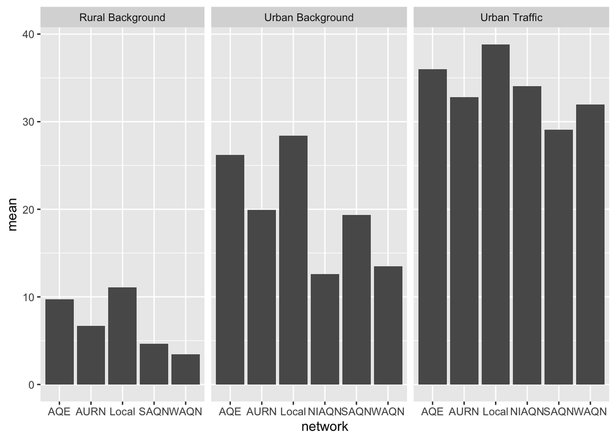

Figure 1: A quick [ggplot2](https://ggplot2.tidyverse.org) figure.

```r
stats_site_type %>%
  filter(site_type %in% c("Rural Background", "Urban Background", "Urban Traffic")) %>%
  ggplot(aes(x = network, y = mean)) +
  geom_col() +
  facet_grid(cols = vars(site_type),
             scales = "free_x",
             space = "free_x")
```

For more general interest, Figure 2 shows a nicer version of the same plot. This is mainly to demonstrate the fine control one can have over plots when using a flexible plotting system like [ggplot2](https://ggplot2.tidyverse.org), so don’t worry if you don’t understand even half of what’s written below!

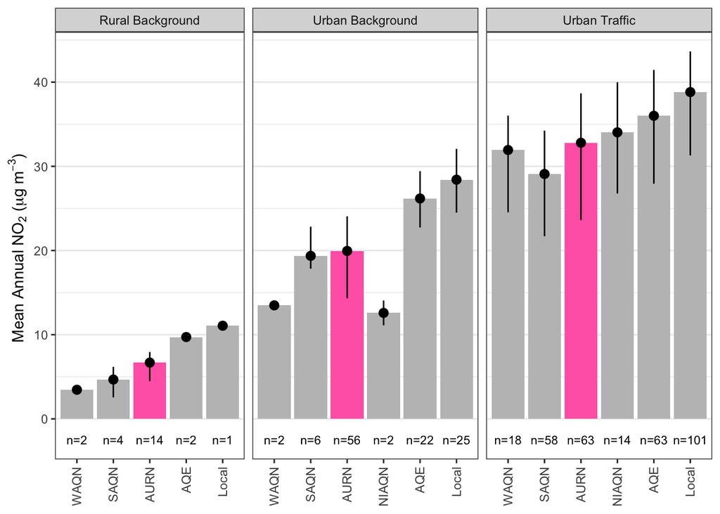

Figure 2: A nicely themed plot.

```r
stats_site_type %>%
  ungroup() %>%
  filter(site_type %in% c("Rural Background", "Urban Background", "Urban Traffic")) %>%
  mutate(network = fct_reorder(network, mean)) %>%
  ggplot(aes(x = network, y = mean)) +
  geom_col(aes(fill = network == "AURN"), show.legend = FALSE) +
  geom_pointrange(aes(ymax = q75, ymin = q25)) +
  geom_text(aes(label = paste0("n=", n), y = -2.5), size = 3) +
  facet_grid(cols = vars(site_type),
             scales = "free_x",
             space = "free_x") +
  theme_bw() +
  theme(axis.text.x = element_text(angle = 90, vjust = .5, hjust = 1),
        panel.grid.major.x = element_blank()) +
  labs(y = quickText("Mean Annual NO2 (ug/m3)"),
       x = NULL) +
  scale_fill_manual(values = c("grey75", "hotpink"))
```

Summary statistics are okay, but they can often hide interesting nuances in the data. Lets instead consider the distribution of annual means. This shows that, while the AURN is in the middle of the networks as far as averages are concerned, it does have at least one large outlier site that rivals the local networks.

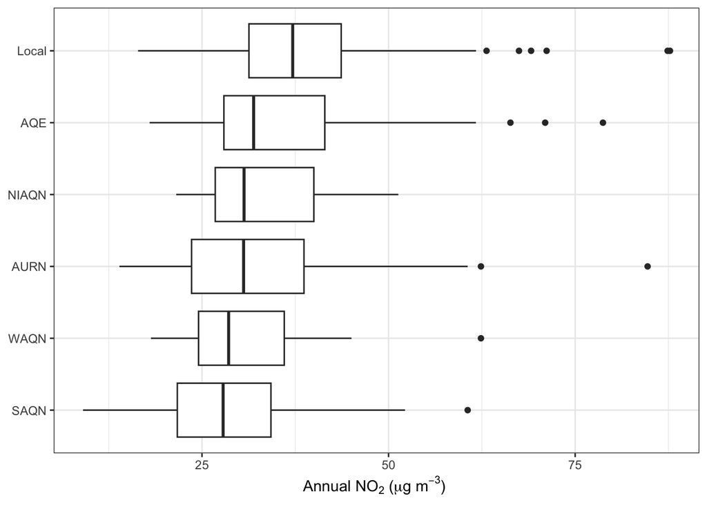

Figure 3: Box plots showing the distributions of the different air quality networks measuring ambient air at Urban Traffic sites.

```r
all_aq %>%
  filter(data_capture > .8,
         species == "no2",
         site_type == "Urban Traffic") %>%
  mutate(network = fct_reorder(network, value)) %>%
  ggplot(aes(y = network, x = value)) +
  geom_boxplot() +
  theme_bw() +
  labs(y = NULL, x = quickText("Annual NO2 (ug/m3)"))
```

# 4 Multiple pollutants

We could choose to examine multiple pollutants at once, such as through a scatter plot (Figure 4). It is clear that sites with higher ozone typically have lower nitrogen dioxide, and vice-versa.

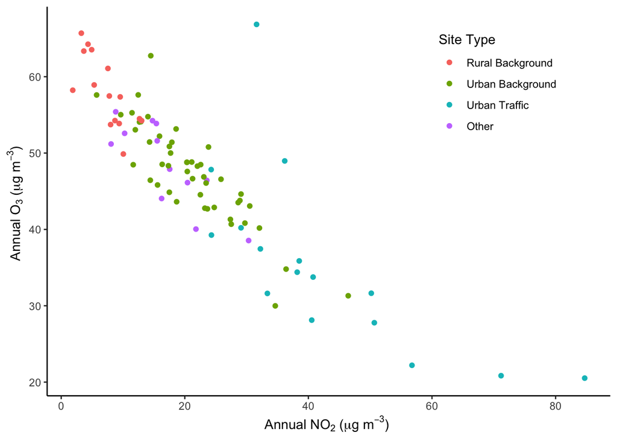

Figure 4: A scatter plot showing the relationship between annual ozone and nitrogen dioxide concentrations.

```r
scatter_data <-
  all_distinct %>%
  # filter dc/species
  filter(data_capture > .8,
         species %in% c("no2", "o3")) %>%
  # select needed columns
  select(site_type, site, species, value) %>%
  # reshape
  pivot_wider(names_from = species, values_from = value) %>%
  # drop missing
  drop_na(no2, o3) %>%
  # lump site types together
  mutate(site_type = fct_lump_n(site_type, n = 3))

scatter_data %>%
  ggplot(aes(x = no2, y = o3)) +
  geom_point(aes(color = site_type)) +
  theme_classic() +
  theme(legend.position = c(.8, .8)) +
  labs(y = quickText("Annual O3 (ug/m3)"),
       x = quickText("Annual NO2 (ug/m3)"),
       color = "Site Type")
```

R is a language built for statistics, so its really easy to examine this relationship in a more robust, statistical way. For example, we could quickly fit a linear model to examine how NO<sub>2</sub> and O<sub>3</sub> are related. We can see that, for every extra 1 unit of NO<sub>2</sub>, O<sub>3</sub> drops by around 0.6 units. The linear model also explains around 76% of the variance in the data.

```r
mod <- lm(o3 ~ no2, scatter_data)

summary(mod)
```

```
Call:
lm(formula = o3 ~ no2, data = scatter_data)

Residuals:
    Min      1Q  Median      3Q     Max
-9.5435 -2.6337  0.1697  1.6462 25.4813

Coefficients:
            Estimate Std. Error t value Pr(>|t|)
(Intercept) 60.54333    0.93202   64.96   <2e-16 ***
no2         -0.60654    0.03565  -17.01   <2e-16 ***
---
Signif. codes:  0 '***' 0.001 '**' 0.01 '*' 0.05 '.' 0.1 ' ' 1

Residual standard error: 4.79 on 89 degrees of freedom
Multiple R-squared:  0.7648,    Adjusted R-squared:  0.7622
F-statistic: 289.4 on 1 and 89 DF,  p-value: < 2.2e-16
```

```r
mod_sites <- lm(o3 ~ no2 * site_type, scatter_data)
summary(mod_sites)
```

```
Call:
lm(formula = o3 ~ no2 * site_type, data = scatter_data)

Residuals:
    Min      1Q  Median      3Q     Max
-8.4869 -2.2590 -0.0834  2.0233 25.8704

Coefficients:
                              Estimate Std. Error t value Pr(>|t|)
(Intercept)                    65.7003     2.9822  22.030   <2e-16 ***
no2                            -1.0455     0.3715  -2.815   0.0061 **
site_typeUrban Background      -3.4296     3.5677  -0.961   0.3392
site_typeUrban Traffic         -8.9194     4.4522  -2.003   0.0484 *
site_typeOther                 -5.1754     4.9356  -1.049   0.2974
no2:site_typeUrban Background   0.3368     0.3816   0.883   0.3800
no2:site_typeUrban Traffic      0.5457     0.3785   1.442   0.1531
no2:site_typeOther              0.3338     0.4310   0.774   0.4409
---
Signif. codes:  0 '***' 0.001 '**' 0.01 '*' 0.05 '.' 0.1 ' ' 1

Residual standard error: 4.678 on 83 degrees of freedom
Multiple R-squared:  0.7909,    Adjusted R-squared:  0.7732
F-statistic: 44.84 on 7 and 83 DF,  p-value: < 2.2e-16
```

We can actually plot this linear model on our graph quite easily. This very clearly shows the similarity between different site types, again with the exception of urban traffic for which the gradient is visually shallower likely owing to some outliers.

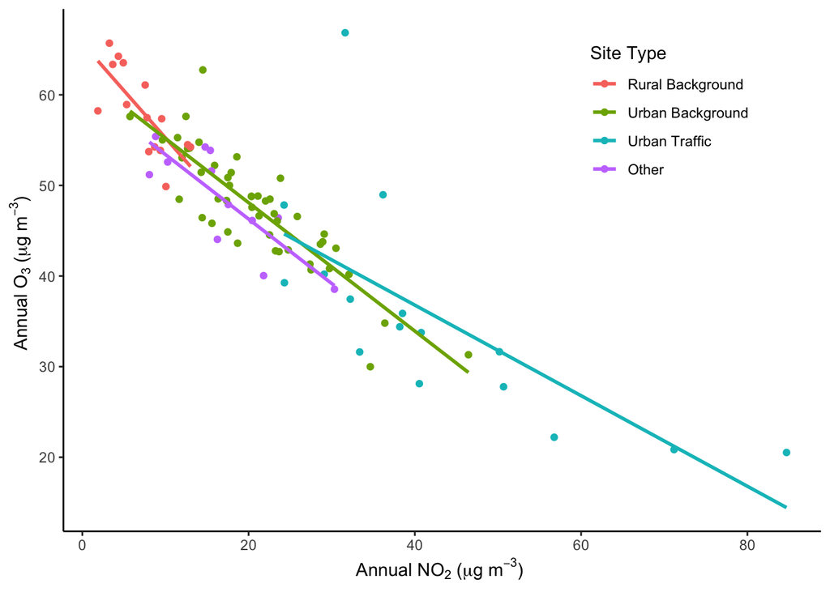

Figure 5: Our linear models shown on a graph.

```r
scatter_data %>%
  ggplot(aes(x = no2, y = o3)) +
  geom_point(aes(color = site_type)) +
  geom_smooth(aes(color = site_type), se = FALSE, method = "lm") +
  theme_classic() +
  theme(legend.position = c(.8, .8)) +
  labs(y = quickText("Annual O3 (ug/m3)"),
       x = quickText("Annual NO2 (ug/m3)"),
       color = "Site Type")
```

# 5 Geographic distributions

Another way to treat this data is by mapping it. One of the easiest ways to do this is through the [leaflet](https://rstudio.github.io/leaflet/) package (not part of the [tidyverse](https://tidyverse.tidyverse.org)) which is demonstrated in Figure 6. This could be described as a “spot concentration” map, which shows the distribution of different annual ozone concentrations.

```r
library(leaflet)

map_data <-
  all_distinct %>%
  filter(data_capture > .8,
         species == "o3")

pal <- colorNumeric(viridis::turbo(n = 100), domain = map_data$value)

leaflet(map_data) %>%
  addProviderTiles("CartoDB.Positron") %>%
  addCircleMarkers(color = ~ pal(value),
                   label = ~ site,
                   popup = ~ str_glue("Ozone: {value} ug/m3"),
                   radius = 2) %>%
  addLegend(pal = pal,
            values = map_data$value,
            title = "O<sub>3</sub>")
```

[interactive chart not shown]

Figure 6: A [leaflet](https://rstudio.github.io/leaflet/) map showing ozone concentrations.